# Analisis de series de tiempo

Alexander Quevedo

10 de mayo de 2018

## Introducción

Las técnicas de percepción remota son una herramienta exitosa para detectar el cambio sobre la superficie terrestre y en la actualidad juegan un papel clave en la estimación de cambios sobre la cubierta vegetal. Esto se debe a dos factores fundamentales: la creciente disponibilidad de repositorios de imágenes satélitales con diferentes resoluciones espaciales y temporales, y el desarrollo de diversos procedimientos de monitoreo para detectar los cambio.

Uno de los procedimientos que está dando mayores resultados en la detección de cambios es el análisis de series de tiempo; éste emplea métodos estadísticos para analizar y modelar observaciones equidistantes en el tiempo. El análisis de series de tiempo para la percepción remota se entiende como el monitoreo temporalmente denso de la dinámica de la superficie terrestre en un periodo definido.

Este método presenta ventajas sobre el método tradicional, en el cual se evalúan dos fechas ya que permite conocer con mayor precisión temporal la ocurrencia del cambio; adicionalmente permite establecer si el cambio se produce debido a una variabilidad en la estacionalidad o es producto de un cambio abrupto en la tendencia de la cubierta.

## Objetivo

Detectar cambios sobre la cobertura forestal usando un algoritmo basado en datos.

## Instalar bfastSpatial

```r
library(raster)
library(devtools)
install_github('loicdtx/bfastSpatial')
# load the package
library(bfastSpatial)
```

## Preprocesamiento de datos

El paquete `bfastSpatial` incluye utilidades para preprocesar los datos de reflectancia de superficie del sensor Landsat y prepararlos para su posterior análisis con las funciones de detección de cambios.

La categoría de preproceso de landsat contiene las siguientes funciones.

- `processLandsat()`: la función base que trae una escena de landsat única de su archivo a una capa ráster de índice de vegetación, recortada hasta cierto punto y con nubes filtradas.
- `processLandsatBatch()`: la implementación de proceso por lotes de `processLandsat()` con soporte de cómputo paralelo.
- `timeStack ()`: una función para crear pilas de raster de capas de índice de vegetación, con un vector de tiempo escrito en las propiedades del objeto.

### Generar capa de índice de vegetación a partir de un archivo de archivo Landsat.

```r
list.files(system.file('external', package='bfastSpatial'), full.names=TRUE)
```

```
## [1] "C:/Users/Rocket/Documents/R/win-library/3.4/bfastSpatial/external/LE70230282011250EDC00_sub.zip"
## [2] "C:/Users/Rocket/Documents/R/win-library/3.4/bfastSpatial/external/LE70230282015250EDC00_sub_fake.zip"
```

El uso del argumento `full.names = TRUE` le permite usar directamente los elementos de la lista create sin tener que establecer directorios de trabajo.

## Proceso en lotes.

```r
srdir <- dirout <- file.path(dirname(rasterTmpFile()), 'bfmspatial_2')
dir.create(dirout, showWarning=FALSE)

dir <- system.file('external', package='bfastSpatial')
processLandsatBatch(x=dir, pattern=glob2rx('*.zip'), outdir=dirout, srdir=srdir, delete=TRUE, vi='ndvi', mask='fmask', keep=0, overwrite=TRUE)
```

```
## [[1]]
## [1] TRUE TRUE
##
## [[2]]
## [1] TRUE TRUE TRUE
```

```r
list <- list.files(dirout, pattern=glob2rx('*.grd'), full.names=TRUE)
```

### Crear un objeto ráster multi-temporal

Una vez que las capas de índice de vegetación se han producido para varias fechas, se pueden apilar para crear un objeto ráster multicapa, con la dimensión de tiempo escrita en el archivo también. La función para realizar esta operación en los datos Landsat es la función timeStack. Simplemente proporcionando una lista de nombres de archivos o un directorio que contenga los archivos, la función creará un objeto de múltiples capas y analizará directamente los nombres de los archivos para extraer información temporal de ellos y escribir esa información en el objeto creado.

```r
list
```

```
## [1] "C:/Users/Rocket/AppData/Local/Temp/RtmpIVtipt/raster/bfmspatial_2/ndvi.LE70230282011250.grd"
## [2] "C:/Users/Rocket/AppData/Local/Temp/RtmpIVtipt/raster/bfmspatial_2/ndvi.LE70230282015250.grd"
```

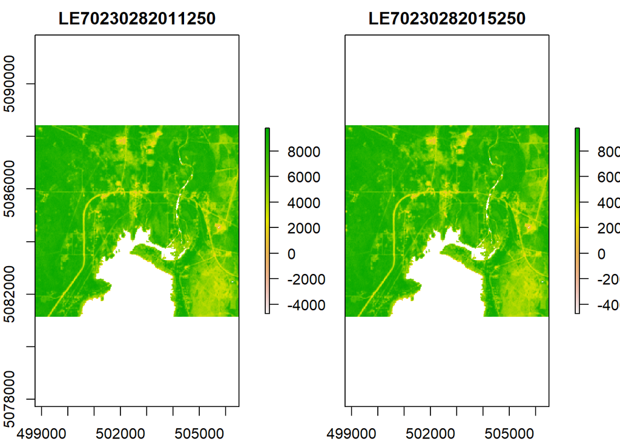

```r
dirout <- file.path(dirname(rasterTmpFile()), 'stack')
dir.create(dirout, showWarnings=FALSE)

stackName <- file.path(dirout, 'stackTest.grd')

s <- timeStack(x=list, filename=stackName, datatype='INT2S', overwrite=TRUE)

plot(s)
```

## Observaciones válidas El número de observaciones disponibles en una serie de tiempo de ráster se puede calcular utilizando `countObs()`. Esta función “perfora” a través de los píxeles de una serie temporal y cuenta el número de píxeles con un valor distinto de NA. Opcionalmente, se puede suministrar cualquier otro valor como sustituto de NA (por ejemplo, también se puede consultar el número de valores distintos de cero por píxel).

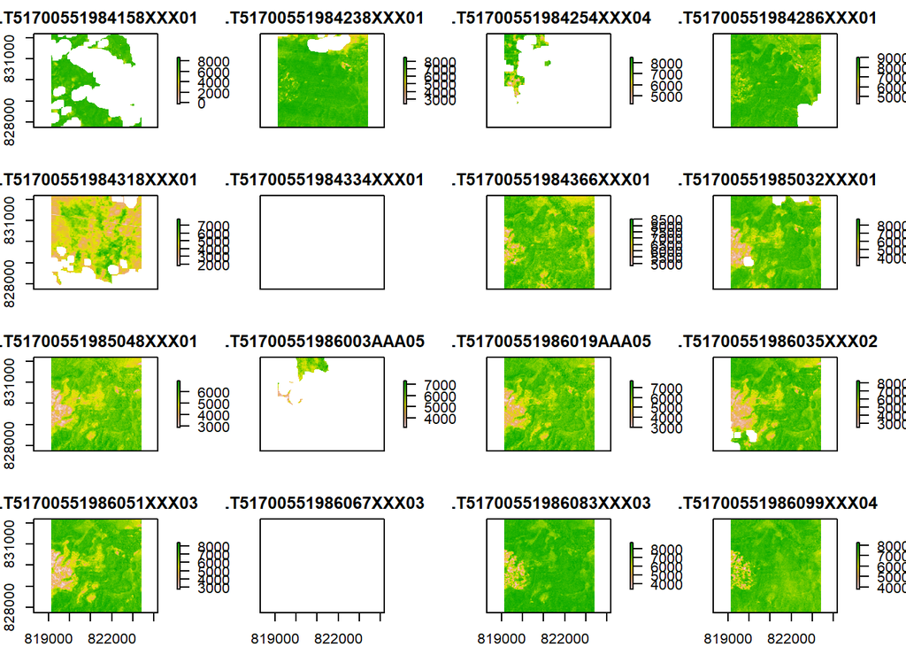

```r
data(tura)
plot(tura)
```

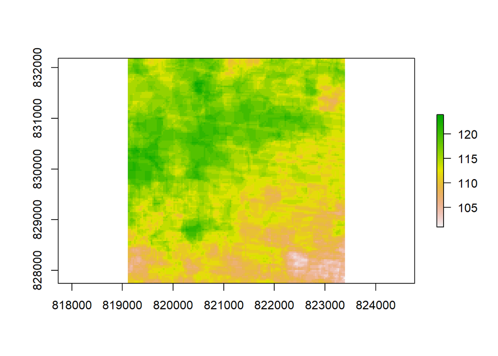

```r
obs <- countObs(tura)
plot(obs)
```

```r
summary(obs)
```

```
##         layer
## Min.      101
## 1st Qu.   112
## Median    114
## 3rd Qu.   117
## Max.      124
## NA's        0
```

Los valores también se pueden expresar como un porcentaje

```r
obs <- countObs(tura, as.perc=TRUE)
summary(obs)
```

```
##            layer
## Min.    60.84337
## 1st Qu. 67.46988
## Median  68.67470
## 3rd Qu. 70.48193
## Max.    74.69880
## NA's     0.00000
```

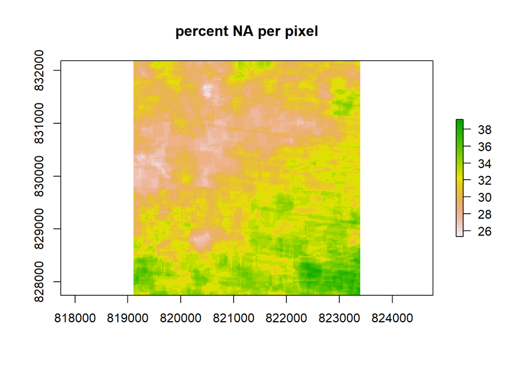

```r
percNA <- 100 - countObs(tura, as.perc=TRUE)
plot(percNA, main="percent NA per pixel")
```

```r
summary(percNA)
```

```
##            layer
## Min.    25.30120
## 1st Qu. 29.51807
## Median  31.32530
## 3rd Qu. 32.53012
## Max.    39.15663
## NA's     0.00000
```

## Resumen estadístico

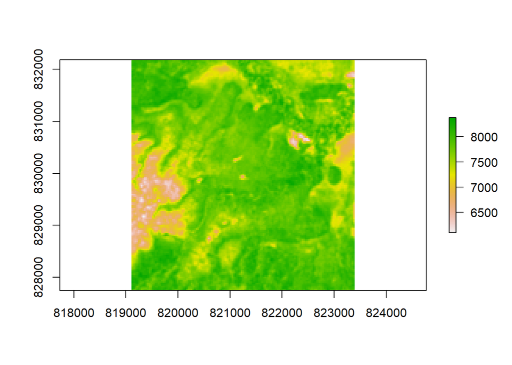

```r
meanVI <- summaryBrick(tura, fun=mean,na.rm=TRUE)
plot(meanVI)
```

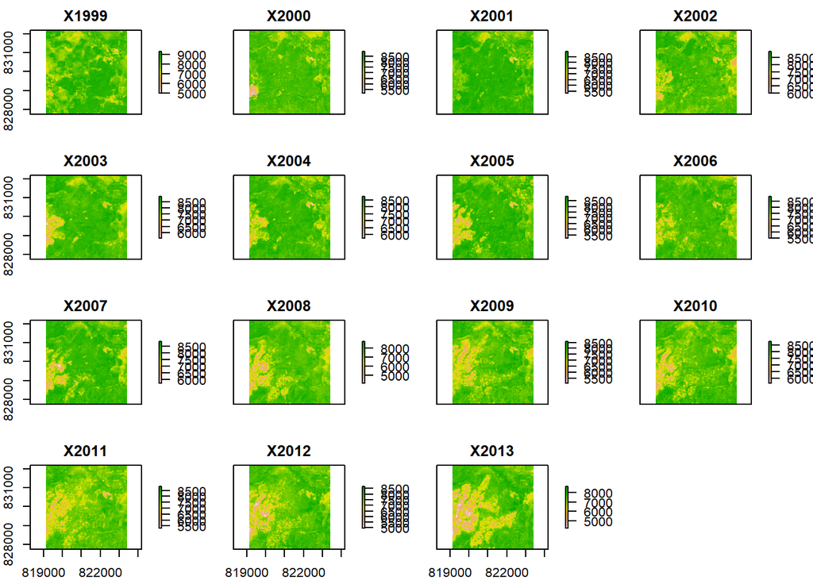

```r
annualMed <- annualSummary(tura, fun=median, sensor="ETM+", na.rm=TRUE)
plot(annualMed)
```